# Bellabeat_capstone

Hawa

2023-04-07

Find some trends from Fitbit data from 12 April 2016 to 12 May 2016.  
There’re 18 files in this dataset. so I choose only 4 files to calculate.  
That is daily activity, heart rate, sleep, and hour calories.  
I also use this file to reference the meaning of some field >> [fitabase](https://www.fitabase.com/media/1930/fitabasedatadictionary102320.pdf)

## Daily activity-step, calories and sedentary data

First of all, I try to find some trends in activity data that involve the step, calories and sedentary data.

Import .csv file and preview the data

```r
install.packages("tidyverse", repos = "http://cran.us.r-project.org")
library(tidyverse)
daily_activity <- read.csv("dailyActivity_merged.csv")
glimpse(daily_activity)
```

```
## Rows: 940
## Columns: 15
## $ Id                       <dbl> 1503960366, 1503960366, 1503960366, 150396036…
## $ ActivityDate             <chr> "4/12/2016", "4/13/2016", "4/14/2016", "4/15/…
## $ TotalSteps               <int> 13162, 10735, 10460, 9762, 12669, 9705, 13019…
## $ TotalDistance            <dbl> 8.50, 6.97, 6.74, 6.28, 8.16, 6.48, 8.59, 9.8…
## $ TrackerDistance          <dbl> 8.50, 6.97, 6.74, 6.28, 8.16, 6.48, 8.59, 9.8…
## $ LoggedActivitiesDistance <dbl> 0, 0, 0, 0, 0, 0, 0, 0, 0, 0, 0, 0, 0, 0, 0, …
## $ VeryActiveDistance       <dbl> 1.88, 1.57, 2.44, 2.14, 2.71, 3.19, 3.25, 3.5…
## $ ModeratelyActiveDistance <dbl> 0.55, 0.69, 0.40, 1.26, 0.41, 0.78, 0.64, 1.3…
## $ LightActiveDistance      <dbl> 6.06, 4.71, 3.91, 2.83, 5.04, 2.51, 4.71, 5.0…
## $ SedentaryActiveDistance  <dbl> 0, 0, 0, 0, 0, 0, 0, 0, 0, 0, 0, 0, 0, 0, 0, …
## $ VeryActiveMinutes        <int> 25, 21, 30, 29, 36, 38, 42, 50, 28, 19, 66, 4…
## $ FairlyActiveMinutes      <int> 13, 19, 11, 34, 10, 20, 16, 31, 12, 8, 27, 21…
## $ LightlyActiveMinutes     <int> 328, 217, 181, 209, 221, 164, 233, 264, 205, …
## $ SedentaryMinutes         <int> 728, 776, 1218, 726, 773, 539, 1149, 775, 818…
## $ Calories                 <int> 1985, 1797, 1776, 1745, 1863, 1728, 1921, 203…
```

I change the column names to prevent me from typing a wrong code. The activity_date column also be character, so I change this column to date.

```r
install.packages("janitor", repos = "http://cran.us.r-project.org")
library(janitor)
daily_activity <- clean_names(daily_activity)
library(lubridate)
daily_activity$activity_date <- mdy(daily_activity$activity_date)
glimpse(daily_activity)
```

```
## Rows: 940
## Columns: 15
## $ id                         <dbl> 1503960366, 1503960366, 1503960366, 1503960…
## $ activity_date              <date> 2016-04-12, 2016-04-13, 2016-04-14, 2016-0…
## $ total_steps                <int> 13162, 10735, 10460, 9762, 12669, 9705, 130…
## $ total_distance             <dbl> 8.50, 6.97, 6.74, 6.28, 8.16, 6.48, 8.59, 9…
## $ tracker_distance           <dbl> 8.50, 6.97, 6.74, 6.28, 8.16, 6.48, 8.59, 9…
## $ logged_activities_distance <dbl> 0, 0, 0, 0, 0, 0, 0, 0, 0, 0, 0, 0, 0, 0, 0…
## $ very_active_distance       <dbl> 1.88, 1.57, 2.44, 2.14, 2.71, 3.19, 3.25, 3…
## $ moderately_active_distance <dbl> 0.55, 0.69, 0.40, 1.26, 0.41, 0.78, 0.64, 1…
## $ light_active_distance      <dbl> 6.06, 4.71, 3.91, 2.83, 5.04, 2.51, 4.71, 5…
## $ sedentary_active_distance  <dbl> 0, 0, 0, 0, 0, 0, 0, 0, 0, 0, 0, 0, 0, 0, 0…
## $ very_active_minutes        <int> 25, 21, 30, 29, 36, 38, 42, 50, 28, 19, 66,…
## $ fairly_active_minutes      <int> 13, 19, 11, 34, 10, 20, 16, 31, 12, 8, 27, …
## $ lightly_active_minutes     <int> 328, 217, 181, 209, 221, 164, 233, 264, 205…
## $ sedentary_minutes          <int> 728, 776, 1218, 726, 773, 539, 1149, 775, 8…
## $ calories                   <int> 1985, 1797, 1776, 1745, 1863, 1728, 1921, 2…
```

I also interest in length of device usage. How long they use their device? So I decided to plot a graph to see how many users still use the device when time passes.

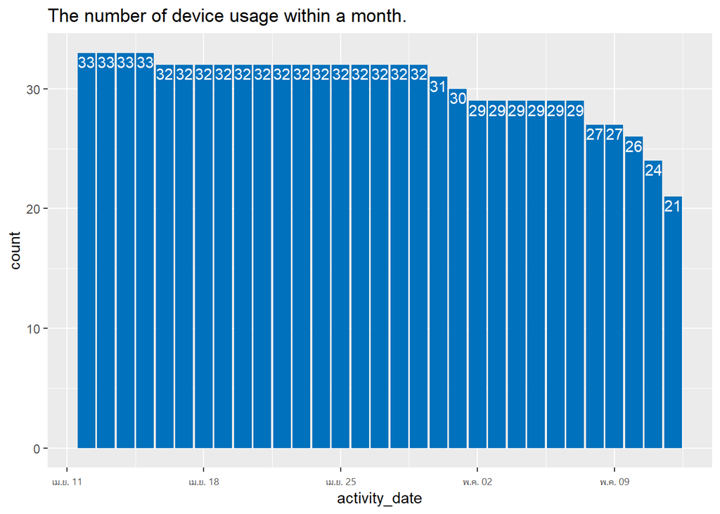

```r
install.packages("ggplot2")
ggplot(data=daily_activity, aes(activity_date))+geom_bar(fill="#0071bc")+
  geom_text(aes(label = ..count..), stat = "count", vjust = 1.25,color = "white")+labs(title = "The number of device usage within a month.")
```

The graph shows that the number of devices usage decreases by 36% when a month passes, the data for the period being relatively short. Maybe it’s better if we get more record days.

In addition, this data may useful for users to gain them more activity. The data show the more steps the more calories burn.

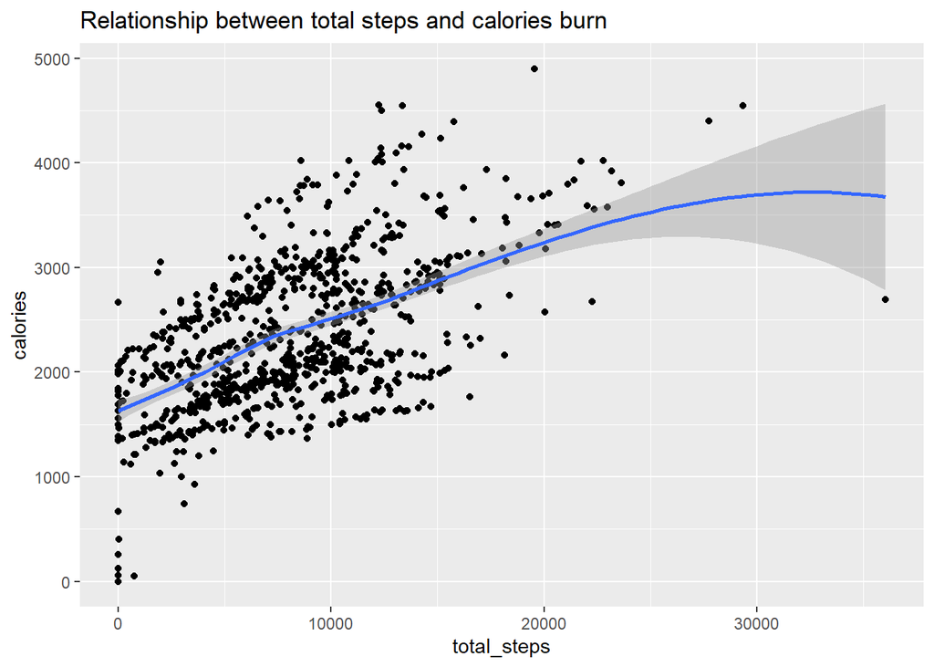

```r
ggplot(data=daily_activity, aes(total_steps,calories))+geom_point()+geom_smooth()+labs(title = "Relationship between total steps and calories burn")
```

## Pattern of heart rate function usage.

Start with import data.

```r
heart_rate <- read.csv("heartrate_seconds_merged.csv")
glimpse(heart_rate)
```

```
## Rows: 2,483,658
## Columns: 3
## $ Id    <dbl> 2022484408, 2022484408, 2022484408, 2022484408, 2022484408, 2022…
## $ Time  <chr> "4/12/2016 7:21:00 AM", "4/12/2016 7:21:05 AM", "4/12/2016 7:21:…
## $ Value <int> 97, 102, 105, 103, 101, 95, 91, 93, 94, 93, 92, 89, 83, 61, 60, …
```

Separate date from time.

```r
heart_rate$Time <- mdy_hms(heart_rate$Time)
heart_rate_sep <- heart_rate %>% separate(Time, into=c("Date","time","shift"), sep=" ") %>% separate(time, into=c("hour","minute","sec"), sep=":")
glimpse(heart_rate_sep)
```

```
## Rows: 2,483,658
## Columns: 7
## $ Id     <dbl> 2022484408, 2022484408, 2022484408, 2022484408, 2022484408, 202…
## $ Date   <chr> "2016-04-12", "2016-04-12", "2016-04-12", "2016-04-12", "2016-0…
## $ hour   <chr> "07", "07", "07", "07", "07", "07", "07", "07", "07", "07", "07…
## $ minute <chr> "21", "21", "21", "21", "21", "22", "22", "22", "22", "22", "22…
## $ sec    <chr> "00", "05", "10", "20", "25", "05", "10", "15", "20", "25", "35…
## $ shift  <chr> NA, NA, NA, NA, NA, NA, NA, NA, NA, NA, NA, NA, NA, NA, NA, NA,…
## $ Value  <int> 97, 102, 105, 103, 101, 95, 91, 93, 94, 93, 92, 89, 83, 61, 60,…
```

Plot a graph.

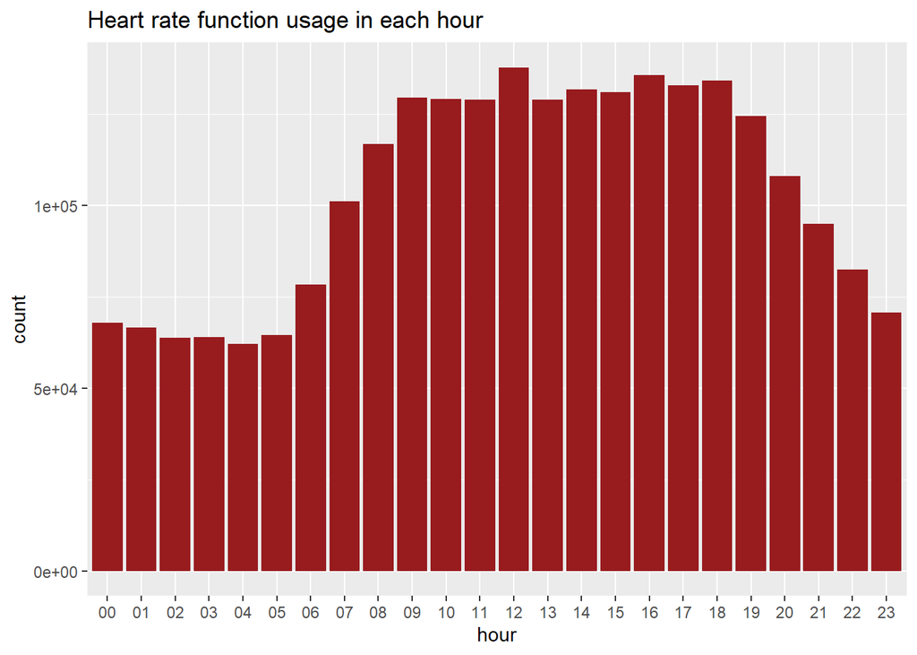

```r
ggplot(data=heart_rate_sep)+ geom_bar(aes(x=hour),fill="#981b1e")+labs(title = "Heart rate function usage in each hour")
```

The graph indicates that heart rate function usage decreases between 23.00 and 6.00. And the next graph shows that the number of heart function usage also decreases when a month passes, similar to other functions.

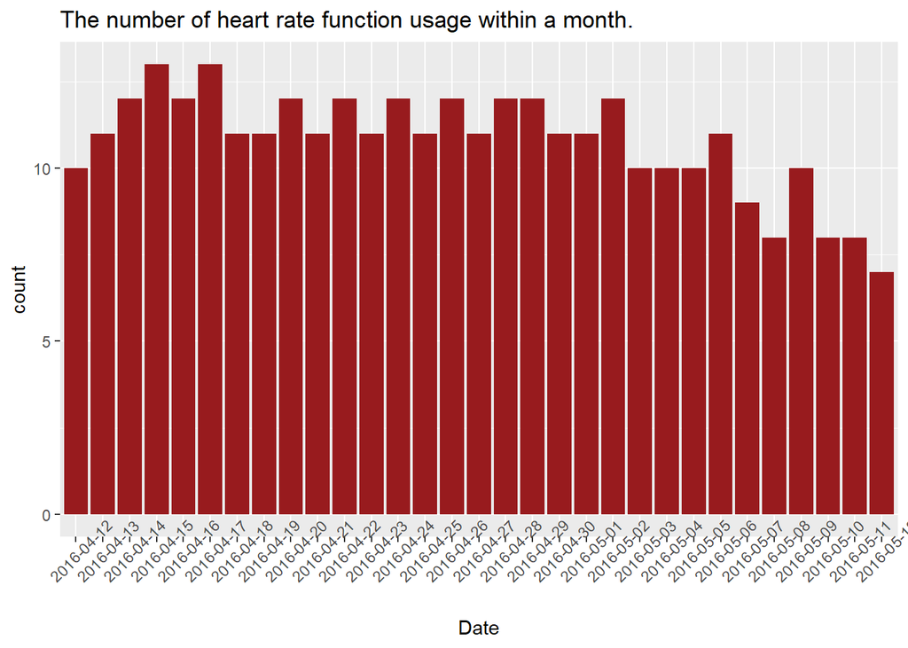

```r
user_heart_active <- heart_rate_sep %>% group_by(Date) %>% summarise(count=n_distinct(Id))
ggplot(data=user_heart_active,aes(x=Date,y=count),)+ geom_col(fill="#981b1e")+theme(axis.text.x = element_text(angle = 45))+labs(title = "The number of heart rate function usage within a month.")
```

For sleep data, I found that the function usage was decreasing as well.

import data

```r
sleep <- read.csv("sleepDay_merged.csv")
glimpse(sleep)
```

```
## Rows: 413
## Columns: 5
## $ Id                 <dbl> 1503960366, 1503960366, 1503960366, 1503960366, 150…
## $ SleepDay           <chr> "4/12/2016 12:00:00 AM", "4/13/2016 12:00:00 AM", "…
## $ TotalSleepRecords  <int> 1, 2, 1, 2, 1, 1, 1, 1, 1, 1, 1, 1, 1, 1, 1, 1, 1, …
## $ TotalMinutesAsleep <int> 327, 384, 412, 340, 700, 304, 360, 325, 361, 430, 2…
## $ TotalTimeInBed     <int> 346, 407, 442, 367, 712, 320, 377, 364, 384, 449, 3…
```

clean data

```r
sleep$SleepDay <- mdy_hms(sleep$SleepDay)
sleep_sep <- sleep %>% separate(SleepDay, into=c("Date","time","shift"), sep=" ")
glimpse(sleep_sep)
```

```
## Rows: 413
## Columns: 7
## $ Id                 <dbl> 1503960366, 1503960366, 1503960366, 1503960366, 150…
## $ Date               <chr> "2016-04-12", "2016-04-13", "2016-04-15", "2016-04-…
## $ time               <chr> NA, NA, NA, NA, NA, NA, NA, NA, NA, NA, NA, NA, NA,…
## $ shift              <chr> NA, NA, NA, NA, NA, NA, NA, NA, NA, NA, NA, NA, NA,…
## $ TotalSleepRecords  <int> 1, 2, 1, 2, 1, 1, 1, 1, 1, 1, 1, 1, 1, 1, 1, 1, 1, …
## $ TotalMinutesAsleep <int> 327, 384, 412, 340, 700, 304, 360, 325, 361, 430, 2…
## $ TotalTimeInBed     <int> 346, 407, 442, 367, 712, 320, 377, 364, 384, 449, 3…
```

First, I find the number of users.

```r
count(sleep,Id)
```

```
##            Id  n
## 1  1503960366 25
## 2  1644430081  4
## 3  1844505072  3
## 4  1927972279  5
## 5  2026352035 28
## 6  2320127002  1
## 7  2347167796 15
## 8  3977333714 28
## 9  4020332650  8
## 10 4319703577 26
## 11 4388161847 24
## 12 4445114986 28
## 13 4558609924  5
## 14 4702921684 28
## 15 5553957443 31
## 16 5577150313 26
## 17 6117666160 18
## 18 6775888955  3
## 19 6962181067 31
## 20 7007744171  2
## 21 7086361926 24
## 22 8053475328  3
## 23 8378563200 32
## 24 8792009665 15
```

Only 24 users report their sleep record and not everyone report full data. And the graph below show that sleep function usage also decrease when time passed as well.

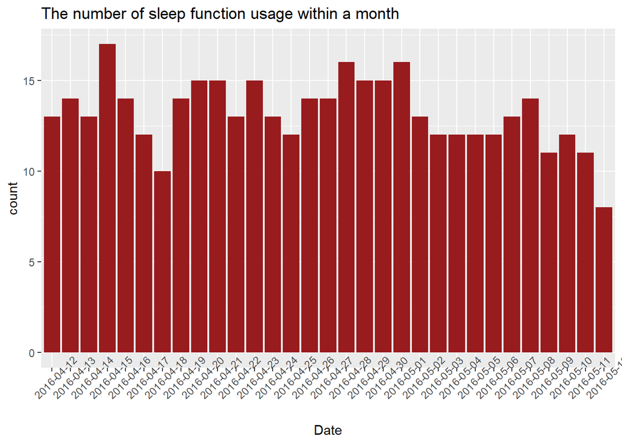

```r
user_sleep_active <- sleep_sep %>% group_by(Date) %>% summarise(count=n_distinct(Id))
ggplot(data=user_sleep_active,aes(x=Date,y=count),)+ geom_col(fill="#981b1e")+theme(axis.text.x = element_text(angle = 45))+labs(title = "The number of sleep function usage within a month")
```

Next, I calculate fall asleep time to see some trends.

```r
fall_asleep <- sleep_sep %>% mutate(fall_asleep_time = TotalTimeInBed -TotalMinutesAsleep)
glimpse(fall_asleep)
```

```
## Rows: 413
## Columns: 8
## $ Id                 <dbl> 1503960366, 1503960366, 1503960366, 1503960366, 150…
## $ Date               <chr> "2016-04-12", "2016-04-13", "2016-04-15", "2016-04-…
## $ time               <chr> NA, NA, NA, NA, NA, NA, NA, NA, NA, NA, NA, NA, NA,…
## $ shift              <chr> NA, NA, NA, NA, NA, NA, NA, NA, NA, NA, NA, NA, NA,…
## $ TotalSleepRecords  <int> 1, 2, 1, 2, 1, 1, 1, 1, 1, 1, 1, 1, 1, 1, 1, 1, 1, …
## $ TotalMinutesAsleep <int> 327, 384, 412, 340, 700, 304, 360, 325, 361, 430, 2…
## $ TotalTimeInBed     <int> 346, 407, 442, 367, 712, 320, 377, 364, 384, 449, 3…
## $ fall_asleep_time   <int> 19, 23, 30, 27, 12, 16, 17, 39, 23, 19, 46, 29, 27,…
```

First, I find the max time user used to fall asleep.

```r
arrange_desc_fallassleep <- fall_asleep %>% arrange(desc(fall_asleep_time))
head(arrange_desc_fallassleep)
```

```
##           Id       Date time shift TotalSleepRecords TotalMinutesAsleep
## 1 1844505072 2016-05-01 <NA>  <NA>                 1                590
## 2 1844505072 2016-04-15 <NA>  <NA>                 1                644
## 3 3977333714 2016-05-01 <NA>  <NA>                 1                383
## 4 1844505072 2016-04-30 <NA>  <NA>                 1                722
## 5 3977333714 2016-04-16 <NA>  <NA>                 1                283
## 6 3977333714 2016-04-24 <NA>  <NA>                 1                310
##   TotalTimeInBed fall_asleep_time
## 1            961              371
## 2            961              317
## 3            626              243
## 4            961              239
## 5            510              227
## 6            526              216
```

The max time is very high, more than 6 hours. And when I detect id filed, it’s look like some users encountered insomnia. Especially, id 3977333714.

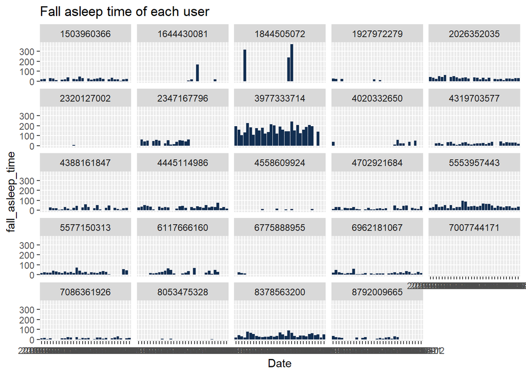

```r
ggplot(data = fall_asleep, aes(x=Date,y=fall_asleep_time))+geom_col(fill="#112e51")+facet_wrap(~Id)+labs(title="Fall asleep time of each user")
```

Next, I find the correlation between sedentary time and sleep time.

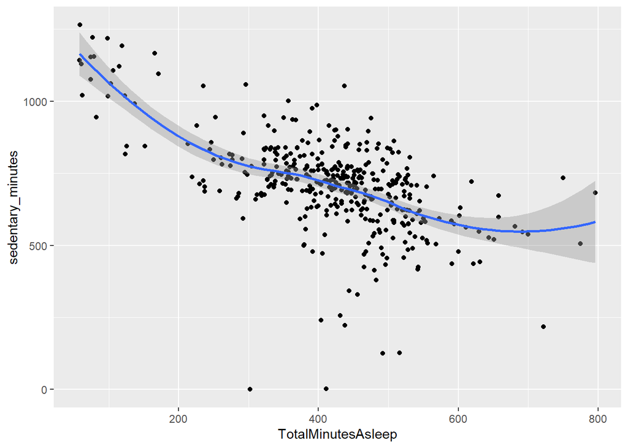

```r
sed_sleep <- merge(daily_activity,sleep_sep, by.x = c("id","activity_date"), by.y = c("Id","Date"))
ggplot(data = sed_sleep, aes(x=TotalMinutesAsleep,y=sedentary_minutes))+geom_point()+geom_smooth()
```

There are correlation between sedentary time and asleep time. When the sedentary time decrease sleep time increase. In other words, more movement in life can increase asleep time.

## Calories burn

Next, I’d like to know overall habit of users about their calories burned. I decided to use Tableau instead.

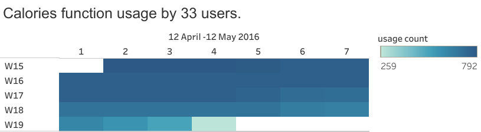

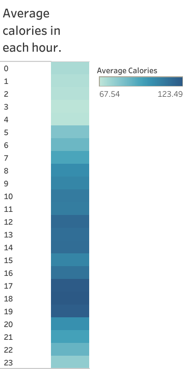

The number of usage decreases when a month nearly end.  
Additional, users burned their calories at 17.00-19.00 the most. Followed by 12.00-14.00.